# WeRateDogs Data Wrangling Project

## Introduction

In this project, the tweet archive of Twitter user @dog_rates, also known as WeRateDogs was used to go through wrangling, analyzing, and visualization practices. WeRateDogs is a Twitter account that rates people's dogs with a humorous comment about the dog. These ratings almost always have a denominator of 10. The numerators, though? Almost always greater than 10. 11/10, 12/10, 13/10, etc. Why? Because "they're good dogs Brent." WeRateDogs has over 4 million followers and has received international media coverage. This project was focused on understanding that real-world data rarely comes in clean and learning how to assess and clean it before analyzing it. A wide variety of Python libraries and functions were used to assess and clean this data and finally analyze it to answer the following three questions:

1. How is the number of original tweets and favorite counts changing over time?
2. What are the top breeds by number of retweets and favorites?
3. Is there a relationship between favorites and retweets?

## Findings

### 1. How is the number of original tweets and favorite counts changing over time?

I would like to take a look at the time series of tweet counts and favorite counts from 2015-2017 that we have the data for. I am curious to see if WeRateDogs got more and more active users or if some similar accounts appeared and stole some of their followers. Below are the time series of tweets, favorites and retweets.

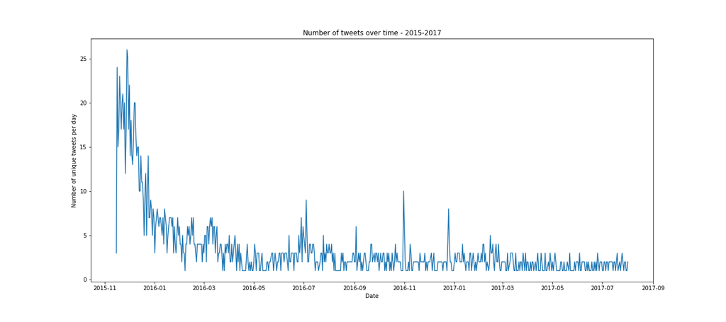

```python
from IPython.display import Image
Image(filename='tweet_count_time_series.png')
```

Strangely, there is a spike and then the number of tweets go down. This could be a data quality issue.

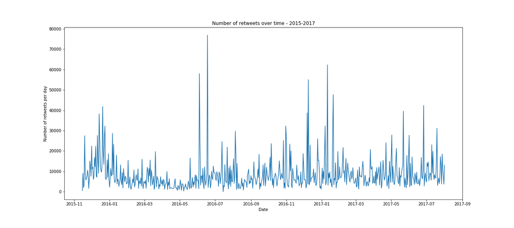

```python
Image(filename='retweet_count_time_series.png')
```

The number of retweets are relatively steady with a slightly increasing trend.

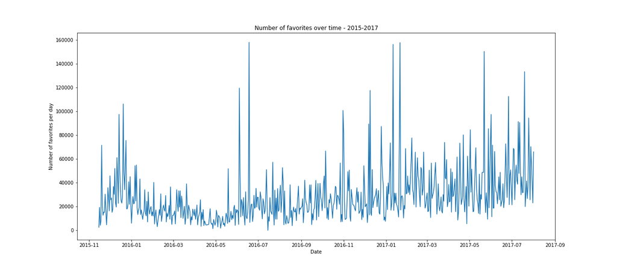

```python
Image(filename='favorite_count_time_series.png')
```

Favorites have a more significant increasing trend over years, this could be because more and more people hear about certain dogs.

### 2. What are the top breeds by number of retweets and favorites?

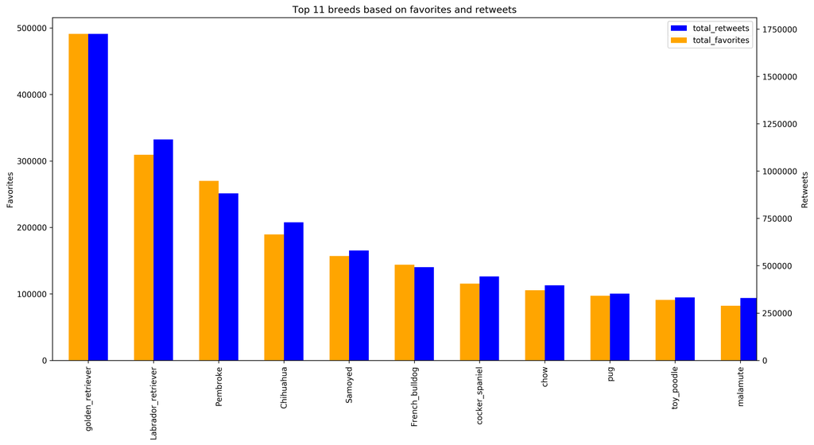

```python
Image(filename='top_breeds_bar.png')
```

[figure not shown]

```python
Image(filename='golden_retriever.jpg')
```

## 3. Is there a relationship between favorites and retweets?

The above bar charts suggest that almost same breeds got highest retweets and favorite. It will be interesting to see if there is any correlation between retweets and favorites. Here we look at the correlation between retweets and favorites color coded by dog life stage. We see below that there is a positive correlation between retweets and favorites. This is to be expected. We also see that many of these are for puppers! Note that since we wanted to color code by dog life stage, rows with stage as None are not included.

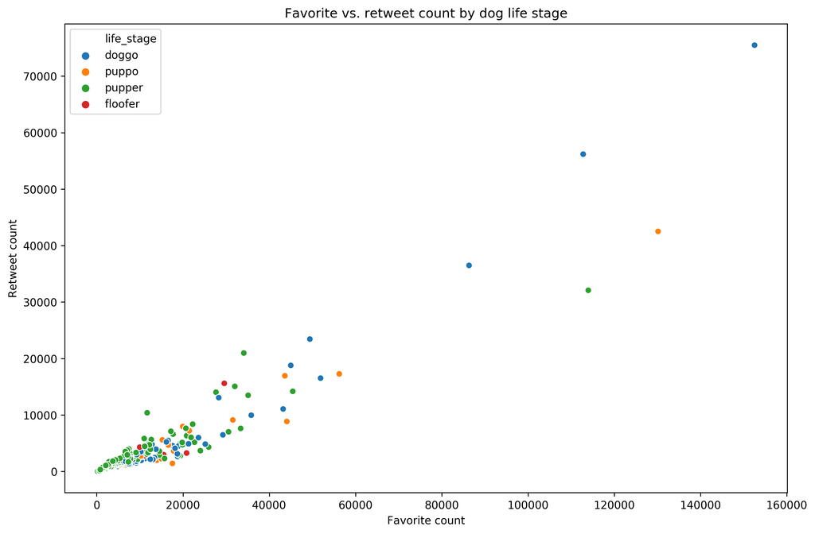

```python
Image(filename='retweet_vs_favorite_scatter.png')
```